# Burkina Faso Social Norms Research transcripts

Ramoudane Orou Sannou

01/10/2020

## 1. Introduction

This is a brief text analysis of interview and focus group transcripts from the study on social norms around the registration of births, marriages, and deaths in Burkina Faso. The study has been conducted at the three Health and Demographic Surveillance System (HDSS) sites in Kaya, Nanoro, and Nouna in Burkina Faso. This analysis provides a typology of the interviewees and reports on the general insights that emerge from the responses given.

```r
library(readtext)     # to read text files
library(readxl)       # to read excel files
library(tidyverse)    # for data manipulation
library(tidytext)     # for text mining
library(tm)           # for text mining
library(stopwords)    # to deal with stop/useless words
library(wordcloud)    # to generate a word cloud
library(widyr)        # for similarity of documents
library(topicmodels)  # for topic modeling
library(knitr)        # for dynamic report generation
```

## 2. Loading the transcripts

```r
nanoro_trans <-
readtext("/Users/ramoudaneorousannou/Downloads/texts_nanoro")


kaya_trans <-
readtext("/Users/ramoudaneorousannou/Downloads/texts_kaya")

nouna_trans <-
readtext("/Users/ramoudaneorousannou/Downloads/texts_nouna")

#head(nanoro_trans)

#head(kaya_trans)

#head(nouna_trans)

# merge all three transcripts into one
transcripts <- bind_rows(nanoro_trans, kaya_trans, nouna_trans)

#str(nanoro_trans)

# adding an excel sheet with more information on the interviwee

info_stakeholders <-
read_excel(path = "/Users/ramoudaneorousannou/Downloads/Transcriptions_Nanoro/Transcriptions.xlsx", sheet = "Sheet1", na = " ")
```

## 3. Types of Interviews

```r
info_stakeholders %>%
group_by(HDSS, Interview_Type) %>%
count() %>%
kable(format = "pipe")
```

| HDSS | Interview_Type | n |
| --- | --- | --- |
| Kaya | Focus group | 16 |
| Kaya | Individuel | 40 |
| Nanoro | Focus group | 12 |
| Nanoro | Individuel | 35 |
| Nouna | Focus group | 30 |
| Nouna | Individuel | 27 |

## 4. Who are the respondents by Gender?

```r
info_stakeholders %>%
group_by(HDSS, Sex) %>%
count() %>%
kable(format = "pipe")
```

| HDSS | Sex | n |
| --- | --- | --- |
| Kaya | Feminin | 14 |
| Kaya | Masculin | 42 |
| Nanoro | Feminin | 9 |
| Nanoro | Masculin | 38 |
| Nouna | Feminin | 17 |
| Nouna | Masculin | 40 |

## 5. Who are the stakeholders by HDSS site?

```r
info_stakeholders %>%
group_by(HDSS, Stakeholder) %>%
count() %>%
kable(format = "pipe")
```

| HDSS | Stakeholder | n |
| --- | --- | --- |
| Kaya | Agent de sante | 4 |
| Kaya | Agent Etat Civil | 1 |
| Kaya | Agent ONG | 2 |
| Kaya | Agent Prefecture | 1 |
| Kaya | Agriculteurs | 9 |
| Kaya | Agricultrices | 6 |
| Kaya | Chef de menage | 6 |
| Kaya | Chef de Village | 2 |
| Kaya | Conseiller municipal | 5 |
| Kaya | CVD | 5 |
| Kaya | Directeur d’ecole | 3 |
| Kaya | Jeunes filles | 3 |
| Kaya | Juge | 1 |
| Kaya | Leader Religieux Chretien | 3 |
| Kaya | Leader Religieux Musulman | 2 |
| Kaya | Pasteur | 1 |
| Kaya | Prefet | 1 |
| Kaya | SG Mairie | 1 |
| Nanoro | Adjoint_Maire | 2 |
| Nanoro | Agent de sante | 4 |
| Nanoro | Agent Etat Civil | 4 |
| Nanoro | Agent ONG | 3 |
| Nanoro | Agriculteurs | 4 |
| Nanoro | Agricultrices | 4 |
| Nanoro | Chef de Village | 2 |
| Nanoro | Conseiller municipal | 7 |
| Nanoro | CVD | 1 |
| Nanoro | Directeur d’ecole | 4 |
| Nanoro | Jeunes filles | 2 |
| Nanoro | Jeunes hommes | 2 |
| Nanoro | Leader Religieux Chretien | 2 |
| Nanoro | Leader Religieux Musulman | 2 |
| Nanoro | Pasteur | 2 |
| Nanoro | Prefet | 2 |
| Nouna | Adjoint_Maire | 2 |
| Nouna | Agent de sante | 3 |
| Nouna | Agent Etat Civil | 1 |
| Nouna | Agent ONG | 1 |
| Nouna | Agent Prefecture | 1 |
| Nouna | Agriculteurs | 14 |
| Nouna | Agricultrices | 16 |
| Nouna | Chef de menage | 4 |
| Nouna | Conseiller municipal | 2 |
| Nouna | CVD | 2 |
| Nouna | Directeur d’ecole | 3 |
| Nouna | Leader Communautaire | 1 |
| Nouna | Leader Religieux Chretien | 2 |
| Nouna | Leader Religieux Musulman | 1 |
| Nouna | Pasteur | 2 |
| Nouna | Prefet | 2 |

```r
transcripts <- bind_cols(transcripts, info_stakeholders)

#head(transcripts)
#str(transcripts)
```

## 6. Who are the respondents by type of interview and gender ?

```r
transcripts_interview_type_sex <- transcripts %>%
group_by(Interview_Type, Sex) %>%
count()

transcripts_interview_type_sex %>%
  kable(format = "pipe")
```

| Interview_Type | Sex | n |
| --- | --- | --- |
| Focus group | Feminin | 30 |
| Focus group | Masculin | 28 |
| Individuel | Feminin | 10 |
| Individuel | Masculin | 92 |

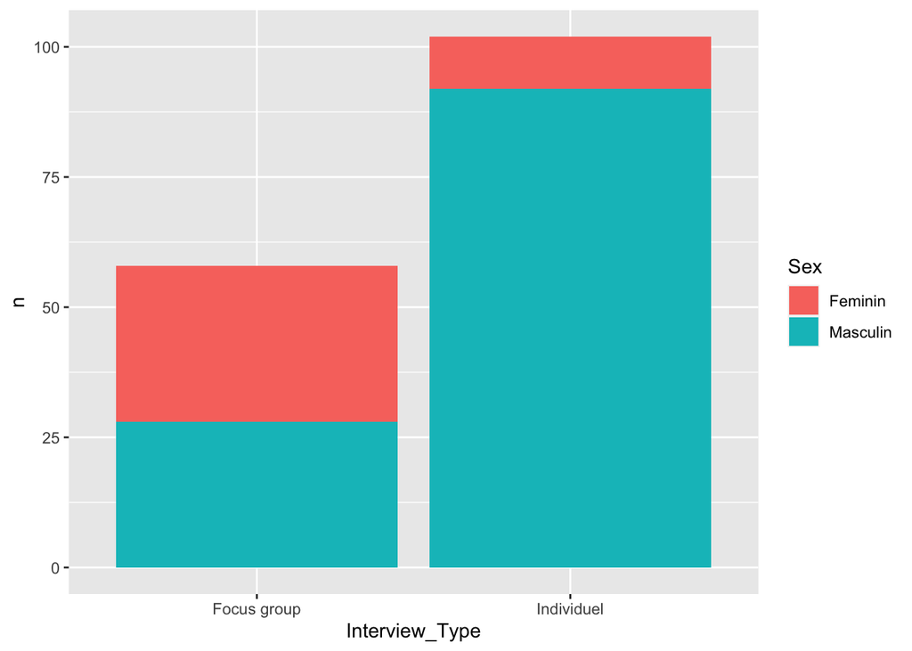

```r
(plot_transcripts_interview_type_sex <- ggplot(transcripts_interview_type_sex, aes(x = Interview_Type, y = n, fill = Sex)) +
geom_col())
```

```r
#nanoro_trans$text <- Corpus(VectorSource(nanoro_trans$text))

#toSpace <- content_transformer(function (x , pattern ) gsub(pattern, " ", x)) # function to replace special charcteres with a space
#nanoro_trans$text <- tm_map(nanoro_trans$text, toSpace, "/")
#nanoro_trans$text <- tm_map(nanoro_trans$text, toSpace, "@")
#nanoro_trans$text <- tm_map(nanoro_trans$text, toSpace, "\\|")

#head(nanoro_trans)
#inspect(nanoro_trans$text)

#nanoro_trans$text <- tm_map(nanoro_trans$text, content_transformer(tolower))

# removing stop words

transcripts_tokens <- transcripts %>%
  unnest_tokens(word, text) %>%
  filter(!word %in% stopwords("fr"))

#nanoro_trans_tokens %>%
#count(word) %>%
#arrange(desc(n)) %>%
#head(50) %>%
#print(n = 50)

# Creating a dataframe of french stop words with tm
fr_stopwords <- tibble(word = stopwords('fr'))
#fr_stopwords

# Creating a new dataframe of words I would like to remove manually

custom_french_stopwords <- tribble( ~word,
                                    "a", "à", "burkina", "aussi", "ainsi", "pays", "faso", "civil", "état", "acte", "actes", "plus", "si", "peut", "être", "faire", "tout", "c'est", "selon", "union", "fait", "comme", "burkinabè", "ouédraogo", "re", "va", "dire", "ouagadougou", "qu’il", "pogbi", "compaoré", "deux", "peut", "un", "ans", "où", "cas", "si", "est", "oui", "chez", "une", "même", "sawadogo", "e", "tre", "probl", "jour", "jours", "quand", "pr", "parce", "r", "p", "o", "b", "donc", "dit", "apr", "r5", "r2", "r6", "r4", "r8", "r9", "koulsoum", "oumou", "tests", "pela", "n7", "r7", "n8", "r1", "r3", "num", "ro", "transcription", "doiga", "n6", "ro7", "ça", "c’est", "là", "n’est", "qu’on", "faut", "n1", "avant", "numéro", "qu'il", "bon", "qu'on", "0", "voilà", "hun", "rn", "chose", "n’y", "talato", "boureima", "000f")

# Joining the created stop words to the standard stop words

fr_stopwords2 <- fr_stopwords %>%
bind_rows(custom_french_stopwords)
#glimpse(fr_stopwords2)

#removing stopwords once again

transcripts_tokens <- transcripts %>%
unnest_tokens(word, text) %>%
anti_join(fr_stopwords2)
```

## 7. Frequent words used by womem

```r
# counting words by sex of interviewee

transcripts_tokens_count <- transcripts_tokens %>%
group_by(Sex) %>%
count(word, sort = T) %>%
top_n(25, n)

transcripts_tokens_count %>%
filter(Sex == "Feminin") %>%
kable(format = "pipe")
```

| Sex | word | n |
| --- | --- | --- |
| Feminin | mariage | 1547 |
| Feminin | naissance | 1331 |
| Feminin | femme | 854 |
| Feminin | décès | 668 |
| Feminin | mairie | 644 |
| Feminin | l’acte | 619 |
| Feminin | gens | 586 |
| Feminin | après | 495 |
| Feminin | enfants | 482 |
| Feminin | bien | 407 |
| Feminin | l’enfant | 406 |
| Feminin | personne | 401 |
| Feminin | certificat | 388 |
| Feminin | font | 384 |
| Feminin | aller | 343 |
| Feminin | fille | 337 |
| Feminin | vont | 333 |
| Feminin | avoir | 318 |
| Feminin | enfant | 315 |
| Feminin | peux | 314 |
| Feminin | non | 311 |
| Feminin | niveau | 309 |
| Feminin | maintenant | 308 |
| Feminin | comment | 306 |
| Feminin | établir | 297 |

## 8. Frequent words used by men

```r
transcripts_tokens_count %>%
filter(Sex == "Masculin") %>%
kable(format = "pipe")
```

| Sex | word | n |
| --- | --- | --- |
| Masculin | naissance | 4578 |
| Masculin | mariage | 4310 |
| Masculin | femme | 2706 |
| Masculin | l’acte | 2034 |
| Masculin | mairie | 1962 |
| Masculin | décès | 1928 |
| Masculin | gens | 1894 |
| Masculin | après | 1595 |
| Masculin | enfants | 1481 |
| Masculin | l’enfant | 1342 |
| Masculin | personne | 1311 |
| Masculin | non | 1305 |
| Masculin | bien | 1298 |
| Masculin | aller | 1288 |
| Masculin | maintenant | 1143 |
| Masculin | papier | 1120 |
| Masculin | vont | 1095 |
| Masculin | peux | 1090 |
| Masculin | fille | 1033 |
| Masculin | avoir | 1028 |
| Masculin | famille | 1018 |
| Masculin | certificat | 1017 |
| Masculin | font | 1012 |
| Masculin | enfant | 1007 |
| Masculin | beaucoup | 955 |

## 9. Word cloud : most frequent words

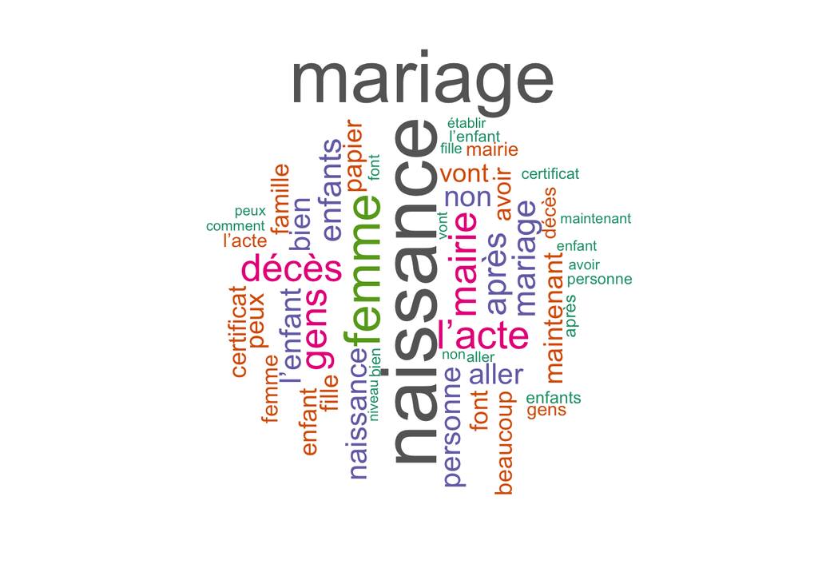

```r
#counting words once again

d <- transcripts_tokens_count %>%
count(word) %>%
arrange(desc(n))

# The importance of words can be illustrated by a word cloud as follows:

set.seed(1234)
wordcloud(words = d$word, freq = d$n, min.freq = 250,
          max.words=200, random.order=FALSE, rot.per=0.35,
          colors=brewer.pal(8, "Dark2"))
```

```r
# Word association
#word_associate(nanoro_trans_tokens$text, match.string = "naissance",
#               stopwords = fr_stopwords2,
#               network.plot = TRUE, cloud.colors = c("gray85", "darkred"))

# Add title
#title(main = "Word Associated to Birth")
```

“Marriage” , “Naissances” and “Femme” are the most commonly used words. Let’s see in what context those words are used by looking at the text that follows the use of each word.

## 10. Text that follows the word “femme” when the interviewee is a woman or a group of women

```r
# Text that follows the word "femme" when the interviewee is a woman or a group of women

transcripts %>%
filter(Sex == "Feminin") %>%
  unnest_tokens(output =  "Femme", input = text,  token = "regex",
                pattern = "(?i)femme" ) %>%
  slice(2:n()) %>%
  select("Femme") %>%
  head(30) %>%
  print(30)
```

```
## readtext object consisting of 30 documents and -1 docvars.
## # Description: df[,2] [30 × 2]
##    Femme                                                                text
##  * <chr>                                                                <chr>
##  1 " accouchaient encore à domicile, ils avaient des difficultés parce… "\"\"..…
##  2 " qui accouchait à soala, à seguedin, à soum, elles accouchaient to… "\"\"..…
##  3 "s accouchent dans les structures de santé, les déclaration de nais… "\"\"..…
##  4 ", puisque  très souvent bon il y a des "                            "\"\"..…
##  5 "s qui quittent le domicile conjugal eeh à l'insu du marie et très … "\"\"..…
##  6 " au tribunal (éclate de rire), nul n'est au-dessus de la honte, il… "\"\"..…
##  7 "moi c’est ouedraogo mady\n33 ans \nje suis allé jusqu’en terminal\… "\"\"..…
##  8 "s prennent elles partent déposer, ou bien elles vont aller donner … "\"\"..…
##  9 " focus group homme\n\nassistant : merci beaucoup. pour vous, dans … "\"\"..…
## 10 " accouche, qu’est-ce que les gens font ?\nouédraogo kader : on fai… "\"\"..…
## 11 " accouche, quelque temps après si l’enfant se porte bien on établi… "\"\"..…
```

[output cut: 19 more lines]

## 11. Text that follows the word “femme” when the interviewee is a man or a group of men

```r
# Text that follows the word "femme" when the interviewee is a man or a group of women

transcripts %>%
filter(Sex == "Masculin") %>%
  unnest_tokens(output =  "Femme", input = text,  token = "regex",
                pattern = "(?i)femme" ) %>%
  slice(2:n()) %>%
  select("Femme") %>%
  head(30) %>%
  print(30)
```

```
## readtext object consisting of 30 documents and -1 docvars.
## # Description: df[,2] [30 × 2]
##    Femme                                                                text
##  * <chr>                                                                <chr>
##  1 ". c’est parce que je suis un  homme qu’on appelle maïeuticien, sin… "\"\"..…
##  2 ", et sage "                                                         "\"\"..…
##  3 " c’est celle qui réalise les accouchements et qui prend en charge … "\"\"..…
##  4 "s comme ça.\naprès 28 jours ce n’est plus nous, puisque si une dam… "\"\"..…
##  5 " c’est jusqu’au 42ème jour. après ces 42 jours si elle ne se sent … "\"\"..…
##  6 "s, parce que les sages "                                            "\"\"..…
##  7 "s et les maïeuticiens ont droit à la prescription. sinon normaleme… "\"\"..…
##  8 " accouche seulement, l’extrait n’est pas obligatoire. si ce n’est … "\"\"..…
##  9 ".\noui\nje peux dire que c’est vice versa. si c’est la dame qui tr… "\"\"..…
## 10 " qui va venir faire sa déclaration de naissance on va la motiver a… "\"\"..…
## 11 "s qui laissent des csps ailleurs pour accoucher ici parce qu’elles… "\"\"..…
```

[output cut: 19 more lines]

The word “femme” seems to be used by men in the same contexts, i.e. when talking about giving birth.

## 12. Text that follows the word “naissance” when the interviewee is a woman or a group of women

```r
# Text that follows the word "naissance" when the interviewee is a woman or a group of women

transcripts %>%
filter(Sex == "Feminin") %>%
  unnest_tokens(output =  "Naissance", input = text,  token = "regex",
                pattern = "(?i)naissance" ) %>%
  slice(2:n()) %>%
  select("Naissance") %>%
  head(30) %>%
  print(30)
```

```
## readtext object consisting of 30 documents and -1 docvars.
## # Description: df[,2] [30 × 2]
##    Naissance                                                            text
##  * <chr>                                                                <chr>
##  1 ", il est très important et nous même, nous avons rencontré des dif… "\"\"..…
##  2 ", parce que les enfants, une fois arrivé en classe de cm2, pour pa… "\"\"..…
##  3 " et il est arrivé un moment où dans certaines écoles il y avait de… "\"\"..…
##  4 ", dans la commune de nanoro, dans la commune de pela on a plusieur… "\"\"..…
##  5 " ce sont déplacées dans les villages avec le financement de respub… "\"\"..…
##  6 " dans les écoles pour faciliter vraiment le travail au niveau de c… "\"\"..…
##  7 " eeh.. on a plusieurs fois financé des activités comme ça.\nbon (r… "\"\"..…
##  8 " c'est l'identité de l'individu, un individu sans identité (rire) … "\"\"..…
##  9 " détermine là d'où vous venez.\nbon, on rencontre souvent quelques… "\"\"..…
## 10 "s, nous finançons mais très souvent nous manquons de retour quoi (… "\"\"..…
## 11 ", leur disponibilité, la lenteur dans l'établissement de ces actes… "\"\"..…
```

[output cut: 19 more lines]

In many cases, the word “birth” is used by women to indicate the importance of having a birth certificate. The importance is linked to having an identity and being able to send children to school. They also mentionned the slowness in establishing birth certificates which would be a blocking factor.

## 13. Text that follows the word “naissance” when the interviewee is a man or a group of men

```r
# Text that follows the word "naissance" when the interviewee is a man or a group of men

transcripts %>%
filter(Sex == "Masculin") %>%
  unnest_tokens(output =  "Naissance", input = text,  token = "regex",
                pattern = "(?i)naissance" ) %>%
  slice(2:n()) %>%
  select("Naissance") %>%
  head(30) %>%
  print(30)
```

```
## readtext object consisting of 30 documents and -1 docvars.
## # Description: df[,2] [30 × 2]
##    Naissance                                                            text
##  * <chr>                                                                <chr>
##  1 " on sait de qui tu es et d’où tu viens, donc c’est important pour … "\"\"..…
##  2 ".\nselon moi l’acte de mariage.\nnon.\nl’acte de mariage ce n’est … "\"\"..…
##  3 ".\ns’ils s’amènent ça, nous on prend le carnet on regarde la date … "\"\"..…
##  4 " avant de remplir. pour remplir maintenant par exemple tu peux écr… "\"\"..…
##  5 " tu dois mettre la date de "                                        "\"\"..…
##  6 ", l’heure de la "                                                   "\"\"..…
##  7 ", le sexe, puis le nom et prénom. normalement on doit établir ça a… "\"\"..…
##  8 ".\noui.\nelle établit et puis elle part à la mairie maintenant\nel… "\"\"..…
##  9 ", c’est vrai qu’après il peut y avoir de petits problèmes si les n… "\"\"..…
## 10 ", par exemple si on refuse de faire ça, quand l’enfant aura l’âge … "\"\"..…
## 11 " aussi tu ne peux avoir de cnib, on se comprend.\nil y a des consé… "\"\"..…
```

[output cut: 19 more lines]

Men seem to refer to the word “naissance” to evoke the important information contained in the birth certificate. They also talk about the difficulty of giving all the information about the new-born systematically after birth. For example, in Muslim families, the child’s first name is known after 7 days.

## 14. Text that follows the word “mariage” when the interviewee is a woman or a group of women

```r
# Text that follows the word "mariage" when the interviewee is a woman or a group of women

transcripts %>%
filter(Sex == "Feminin") %>%
  unnest_tokens(output =  "Mariage", input = text,  token = "regex",
                pattern = "(?i)mariage" ) %>%
  slice(2:n()) %>%
  select("Mariage") %>%
  head(30) %>%
  print(30)
```

```
## readtext object consisting of 30 documents and -1 docvars.
## # Description: df[,2] [30 × 2]
##    Mariage                                                              text
##  * <chr>                                                                <chr>
##  1 " dépend de l'objectif recherché par les couples, l’acte de "        "\"\"..…
##  2 " dépend de l’objectif rechercher par le couple.\nl’acte de "        "\"\"..…
##  3 ", je vous dis que ça dépend de la vision du couple (rire)\nl'impor… "\"\"..…
##  4 " dans le milieu ici, il faut se dire que la population n'a pas eeh… "\"\"..…
##  5 ", au niveau de la population c'est encore un tabou pour eux, ils n… "\"\"..…
##  6 ", puisse il faut se dire que mbon dans la plupart ici mbon, il y a… "\"\"..…
##  7 ", donc ça veut dire qu'il ne comprennent pas, parce que s'ils comp… "\"\"..…
##  8 " ce document-là peut servir, et il faut veiller à avoir ce papier … "\"\"..…
##  9 " ici, oui ils ne connaissent pas, sinon beaucoup de gens le feraie… "\"\"..…
## 10 " (riant), ça veut dire qu'ils s'assument, quand on a fait un acte … "\"\"..…
## 11 ", pour se séparer il y a divorce, il faut quand on a signer un act… "\"\"..…
```

[output cut: 19 more lines]

The texts following the word ‘’marriage’’ are rather ambiguous. Some people think that marriage registration depends on the goals the couple has set for themselves, others allude to the fact that it is difficult to end a registered marriage.

## 15. Text that follows the word “mariage” when the interviewee is a man or a group of men

```r
# Text that follows the word "mariage" when the interviewee is a man or a group of men

transcripts %>%
filter(Sex == "Masculin") %>%
  unnest_tokens(output =  "Mariage", input = text,  token = "regex",
                pattern = "(?i)mariage" ) %>%
  slice(2:n()) %>%
  select("Mariage") %>%
  head(30) %>%
  print(30)
```

```
## readtext object consisting of 30 documents and -1 docvars.
## # Description: df[,2] [30 × 2]
##    Mariage                                                              text
##  * <chr>                                                                <chr>
##  1 ".\nnon.\nl’acte de "                                                "\"\"..…
##  2 " ce n’est pas simple.\nil n’y a pas de soucis.\nselon moi l’import… "\"\"..…
##  3 ".\nc’est le médecin.\non peut déléguer genre les sages femmes, par… "\"\"..…
##  4 " et puis divorcer au bout de 6 mois, et aussi pour aller faire le " "\"\"..…
##  5 " il y a beaucoup qui veulent bien commun. par exemple si la dame v… "\"\"..…
##  6 " religieux ou coutumier. selon moi il y a beaucoup qui pensent com… "\"\"..…
##  7 " est très capital. si par exemple vous vivez en concubinage comme … "\"\"..…
##  8 " et de décès là, ce sont des questions que vous m’avez posé surtou… "\"\"..…
##  9 ", c’est bel et bien que à l’école de formation là on nous parle de… "\"\"..…
## 10 " là. est-ce que pour le "                                           "\"\"..…
## 11 " là vous pouvez m’éclaircir ?\nça va.\nvous deviez prévenir.\n\n\n" "\"\"..…
```

[output cut: 19 more lines]

Difficulties relating to marriage registration are mentioned by men here, including fear of divorce, stereotypes about the division of property in the event of divorce and the preference given to religious and customary marriage in the community.

## 16. Word weights accross interviews

The weight indicator we are using is the Term Frequency Inverse Document Frequency matrix (TFIDF). TFIDF is a way of representing word counts by considering two components.

- The Term Frequency (TF) which is the proportion of words in the text that are that specific term,
- The Inverse Document Frequency (IDF) which is the weight of how common a term is across all documents.

TFIDF is obtained by multuplying the two weights together.

```r
# word weights accross interviews

word_weights <- transcripts_tokens %>%
  count(word, doc_id) %>%
  bind_tf_idf(word, doc_id, n)

#the highest Term Frequency Inverse Document Frequency (TFIDF) matrix

word_weights %>%
  arrange(desc(tf_idf)) %>%
  head(10)
```

```
## readtext object consisting of 10 documents and 4 docvars.
## # Description: df[,7] [10 × 7]
##   word        doc_id                               n     tf   idf tf_idf text
## * <chr>       <chr>                            <int>  <dbl> <dbl>  <dbl> <chr>
## 1 assistant   13_Focus_group_Femmes_24Plus_Ko…    61 0.0409  3.69 0.151  "\"\".…
## 2 assistant   37_Conseiller_Municipal_Kaya.txt    82 0.0276  3.69 0.102  "\"\".…
## 3 assistant   14_Focus_group_Hommes_24Plus_Ta…    49 0.0183  3.69 0.0673 "\"\".…
## 4 d’instruct… 44_Jeunes_Filles_Zoetgomde.txt       7 0.0130  5.08 0.0662 "\"\".…
## 5 ouedraogo   7_Focus_group_Femmes_24Plus_Dam…    50 0.0234  2.18 0.0511 "\"\".…
## 6 santi       16_Focus_group_Jeunes_Filles_Ta…    21 0.0114  4.38 0.0497 "\"\".…
## # … with 4 more rows
```

```r
# the lowest non-zero TFIDF values
word_weights %>%
  filter(tf_idf != 0) %>%
  arrange(tf_idf)%>%
  head(10)
```

```
## readtext object consisting of 10 documents and 4 docvars.
## # Description: df[,7] [10 × 7]
##   word  doc_id                            n       tf     idf     tf_idf text
## * <chr> <chr>                         <int>    <dbl>   <dbl>      <dbl> <chr>
## 1 femme 6_Prefet_Dokuy.txt                1 0.000711 0.00627 0.00000446 "\"\"..…
## 2 gens  49_Directeur_Ecole_Bourasso.…     1 0.000902 0.00627 0.00000565 "\"\"..…
## 3 femme 26_Etat_Civil_Soaw.txt            1 0.000913 0.00627 0.00000573 "\"\"..…
## 4 gens  26_Etat_Civil_Soaw.txt            1 0.000913 0.00627 0.00000573 "\"\"..…
## 5 après 11_Leader_Religieux_Nouna.txt     2 0.000930 0.00627 0.00000583 "\"\"..…
## 6 après 54_Agent_de_la_mairie_Nouna.…     2 0.000931 0.00627 0.00000583 "\"\"..…
## # … with 4 more rows
```

We see that We see that ‘femme’ has very low values for some transcrips. This could be because the word was mentioned just a few times in that article, or because it was used in too many articles.

## 17. Topic Modeling

The collection of transcripts is likely to be made up of a collection of topics. As such, algorithms can identify topics in a collection of texts and one of the most commonly used algorithm for topic modeling is Latent Dirichlet Allocation (LDA).

```r
#topic modeling for sentences that mentionned the word 'mariage'

sentences_mariage <-
transcripts %>%
unnest_tokens(output =  "sentences", input = text,  token = "regex",
                pattern = "(?i)mariage" )


sentences_mariage_tokens <-
sentences_mariage %>%
unnest_tokens(output = "word", input = sentences, token = "words") %>%
anti_join(fr_stopwords2)

mariage_tokens_matrix <-
sentences_mariage_tokens %>%
count(doc_id, word) %>%
cast_dtm(document = doc_id, term = word, value = n)

mariage_LDA <- LDA(mariage_tokens_matrix, k = 10, method = 'Gibbs', control = list(seed = 42))
mariage_beta <- tidy(mariage_LDA, matrix = "beta")

#mariage_beta
 # Topic #3
mariage_beta %>%
  filter(topic == 3) %>%
  arrange(-beta) %>%
  head(50) %>%
  print(n = 50)
```

```
## # A tibble: 50 x 3
##    topic term               beta
##    <int> <chr>             <dbl>
##  1     3 lorsque         0.0156
##  2     3 femme           0.0132
##  3     3 après           0.0131
##  4     3 mairie          0.0126
##  5     3 l’enfant        0.0101
##  6     3 fille           0.00972
##  7     3 décès           0.00919
##  8     3 famille         0.00884
##  9     3 d’autres        0.00778
## 10     3 garçon          0.00766
## 11     3 religions       0.00766
## 12     3 baptême         0.00725
```

[output cut: 38 more lines]

```r
  #Topic #4
mariage_beta %>%
  filter(topic == 4) %>%
  arrange(-beta)%>%
  head(50) %>%
  print(n = 50)
```

```
## # A tibble: 50 x 3
##    topic term            beta
##    <int> <chr>          <dbl>
##  1     4 niveau       0.0143
##  2     4 famille      0.0113
##  3     4 parents      0.00867
##  4     4 puisse       0.00623
##  5     4 très         0.00611
##  6     4 moment       0.00586
##  7     4 difficultés  0.00586
##  8     4 fois         0.00574
##  9     4 question     0.00556
## 10     4 sinon        0.00544
## 11     4 document     0.00537
## 12     4 doit         0.00519
```

[output cut: 38 more lines]

Although it is quite difficult to make sense of these two topics, it seems that most of the words that come after the word “marriage” are common terms such as “women”, “birth”, “town hall”, etc. There are virtually no words related to social norms and customs.

After some attempts at topic modelling, there is a general feeling that the data collected by the HDSS sites focus mainly on the provision of civil registration services or on the reasons why people are reluctant to register their vital events, and not on the social norms surrounding the registration of those events. Therefore, additional data may need to be collected after recalibration of the questionnaire.